# Advanced Geo-Processing

## Future rainfall

Ok, were are ready for the second step; this is downloading the future precipitation. Note that we need to specify what CMIP6 predictions we want (ie ssp, model and year). Let us just use an example to test our code (ie the CNRM-CM6-1 model based on scenario 585 for the period 2041-2060). See the course LGEO1232 ‘Le Climat et ses Changements’ for more info ;-)

[figure not shown]

```r
prec_f50 <- cmip6_world("CNRM-CM6-1", "585", "2041-2060", var="prec", res=5)
plot(prec_f50)
```

```r
start_time <- Sys.time()
prec_f50_DRC <- prec_f50 %>% crop(DRC) %>% mask(DRC)
end_time <- Sys.time()
end_time - start_time
```

```
## Time difference of 0.1156991 secs
```

Ok, easy. Now let us try to use a slightly more advanced way of plotting the data using `mapview`. Make sure you have installed the packages but you already knew that …. We want to plot the total annual rainfall for the present and future conditions side by side so you can easily compare.

```r
Annual_prec_DRC <- sum(Prec_DRC)
Annual_prec_2050_DRC <- sum(prec_f50_DRC)
library(mapview)
map1 <- mapview(Annual_prec_DRC, col.regions=cols, na.color = "transparent")
leaflet::addMiniMap(map1@map)
```

[interactive chart not shown]

```r
library(leaflet.extras2)
#at <- seq(minmax(Annual_prec_DRC)[1],minmax(Annual_prec_DRC)[2],length.out = 8)
at <- seq(800,2500,length.out = 6)
m1 <- mapview(Annual_prec_DRC, col.regions = cols, at = at, na.color = "transparent")
m2 <- mapview(Annual_prec_2050_DRC, col.regions = cols, at = at, na.color = "transparent")

library(leafsync)
m <- leafsync::sync(m1, m2)
m
```

[interactive chart not shown]

Note that you can save maps created with mapview by using the mapshot() function of mapview as an HTML file or as a PNG, PDF, or JPEG image. Try out `htmltools::save_html(m, "m.html")` to save the leafsync map as an html file.

## Change in Rainfall

```r
delta_annual <- sum(prec_f50_DRC-Prec_DRC)
names(delta_annual) <- "Difference"
mapview(delta_annual, col.regions=cols, na.color = "transparent")
```

[interactive chart not shown]

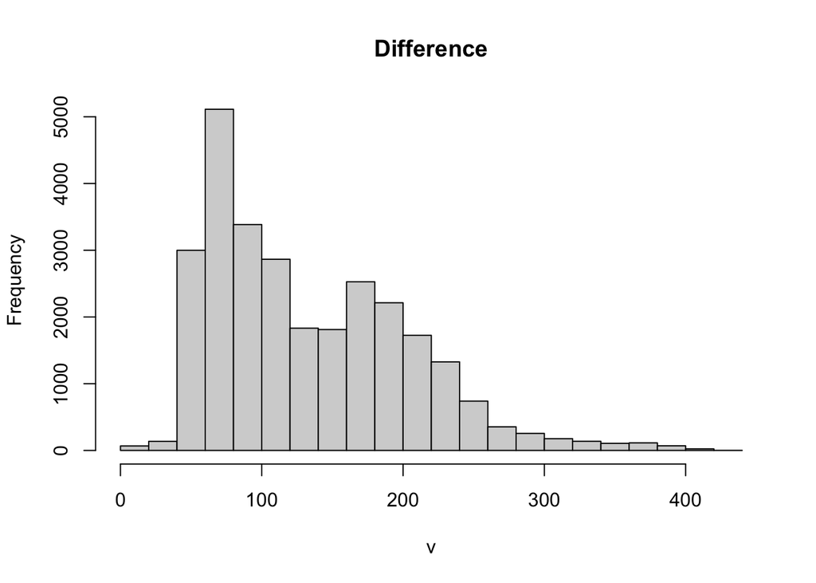

```r
hist(delta_annual)
```

## A general workflow

This was easy, but how can we ‘generalize’ this? for this we need to break the workflow down into its components. We do this by making a flowchart of the workflow:

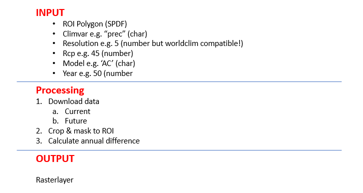

## To a function

The next step is to put this into a single function. Note that all the input variables or the arguments are described in my function, as well as the output. Note that I use a `list` as a result of the function as I have more than 1 output. This is particullarly useful when dealing with outputs from different classes! [more info on lists here](https://rstudio.github.io/r-manuals/r-intro/Lists-and-data-frames.html)

```r
myfunction_Prec_Change <- function(ROI,res,ssp,model,year) {
  #### Description: Function to estimate changes in precipitation using CMIP model scenarios
  #### Input: ROI (SpatVector), res (resolution 2.5 5 or 10),
  #### ssp (Shared Socio-economic Pathway code: "126", "245", "370" or "585".) model (see https://www.worldclim.org/data/cmip6/cmip6climate.html)
  #### year (future year/period One of "2021-2040", "2041-2060", or "2061-2080")
  #### Output: a list (!) with two rasters in unit mm with absolute & relative change relative to current precipitation

  #### download data
  current <- worldclim_global(var="prec",res=res)
  future <- cmip6_world(model, ssp, year, var="prec", res=res)

  #### clip to ROI
  current <- current %>% crop(ROI) %>% mask(ROI)
  future <- future %>% crop(ROI) %>% mask(ROI)

  #### Calculate annual change
  delta_annual <- sum(future -current)
  delta_prec <- sum(future - current)/sum(current)

  return(list(abs_chang = delta_annual, rel_change = delta_prec))
}
```

## Testing your function

You can now use this function to estimate changes for other regions, lets try it for Belgium:

```r
BEL <- gadm(country="BEL", level=0)
test <- myfunction_Prec_Change(ROI=BEL,res=2.5,ssp="585",model= "CNRM-CM6-1", year="2041-2060")
m_abs <- mapview(test$abs_chang, col.regions=cols, na.color = "transparent")
m_rel <- mapview(test$rel_chang, col.regions=cols, na.color = "transparent")
leafsync::sync(m_abs, m_rel)
```

[interactive chart not shown]

This is a very simple function; In the assignment (below), were going to increase the complexity.

# Aggregate maps

For your information, it is straightforward to extract statistics for a given region using the extract function of the `terra`package. Assume you want to summarize the changes in precipitation by 2050 at the provincial level for Belgium, you could use the following code. Why do we need to add `$sum` when extracting the mean values for each polygon? We can plot this the updated `SpatVector` named `BEL_lvl2`using

```r
BEL_lvl2 <- gadm(country="BEL", level=2)
test <- myfunction_Prec_Change(ROI=BEL_lvl2,res=2.5,ssp="585",model= "CNRM-CM6-1", year="2041-2060")

# Average raster values by polygon
BEL_lvl2$avg <- terra::extract(test$abs_chang, BEL_lvl2, mean, na.rm = TRUE)$sum
```

## ggplot2

The **ggplot2** package ([Wickham, Chang, et al. 2022](https://www.paulamoraga.com/book-spatial/references.html#ref-R-ggplot2)) allows us to create graphics based on the grammar of graphics that defines the rules of structuring mathematic and aesthetic elements to build graphs layer-by-layer.

To create a plot with **ggplot2**, we call [ggplot()](https://ggplot2.tidyverse.org/reference/ggplot.html) specifying arguments `data` which is a data frame with the variables to plot, and `mapping = aes()` which are aesthetic mappings between variables in the data and visual properties of the objects in the graph such as position and color of points or lines.

Then, we use `+` to add layers of graphical components to the graph. Layers consist of geometries, stats, scales, coordinates, facets, and themes. For example, we add objects to the graph with `geom_*()` functions (e.g, [geom_point()](https://ggplot2.tidyverse.org/reference/geom_point.html) for points, [geom_line()](https://ggplot2.tidyverse.org/reference/geom_path.html) for lines). We can also add color scales (e.g., [scale_colour_brewer()](https://ggplot2.tidyverse.org/reference/scale_brewer.html)), faceting specifications (e.g., [facet_wrap()](https://ggplot2.tidyverse.org/reference/facet_wrap.html) splits data into subsets to create multiple plots), and coordinate systems (e.g., [coord_flip()](https://ggplot2.tidyverse.org/reference/coord_flip.html)).

We can create maps by using the [geom_sf()](https://ggplot2.tidyverse.org/reference/ggsf.html) function and providing a simple feature (`sf`) object. The figure belows shows our data plotted with **ggplot2** and with viridis scale from the **viridis** package ([Garnier 2021](https://www.paulamoraga.com/book-spatial/references.html#ref-R-viridis)).

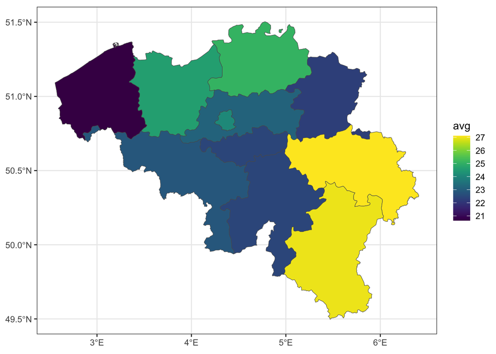

```r
library(ggplot2)
library(viridis)
ggplot(BEL_lvl2) + geom_sf(aes(fill = avg)) +
  scale_fill_viridis() + theme_bw()
```

Plots created with **ggplot2** can be saved with the [ggsave()](https://ggplot2.tidyverse.org/reference/ggsave.html).

The **plotly** package (Sievert, Parmer, et al. 2022) can be used in combination with **ggplot2** to create an interactive plot.You can turn a static `ggplot` object to an interactive `plotly` object by calling the [ggplotly()](https://rdrr.io/pkg/plotly/man/ggplotly.html) function of **plotly** providing the `ggplot` object:

```r
library(plotly)
library(sf)
BEL_mp <- disagg(BEL_lvl2)
g <- ggplot(BEL_mp) + geom_sf(aes(fill = avg))
ggplotly(g)
```

[interactive chart not shown]

## Leaflet

The leaflet package [Cheng, Karambelkar, and Xie 2022](https://www.paulamoraga.com/book-spatial/references.html#ref-R-leaflet) makes it easy to create maps using `Leaflet` which is a very popular open-source JavaScript library for interactive maps. We can create a leaflet map by calling the `leaflet()` function passing the spatial object, and adding layers such as polygons and legends using a number of functions. You can also use the `addMiniMap()` function to add an inset map

```r
pal <- colorNumeric(palette = "YlOrRd", domain = BEL_lvl2$avg)
l <- leaflet(BEL_lvl2) %>% addTiles() %>%
  addPolygons(color = "white", fillColor = ~ pal(avg),
              fillOpacity = 0.8) %>%
  addLegend(pal = pal, values = ~avg, opacity = 0.8)
l
```

[interactive chart not shown]

## Mapview

The mapview package [Appelhans et al. 2022](https://www.paulamoraga.com/book-spatial/references.html#ref-R-mapview) allows us to very quickly create similar interactive maps as leaflet. You just need to use the `mapview()` function passing as arguments the spatial object and the variable to plot. See below. This map is interactive and by clicking each of the areas we can see popups with the data information. Nice!

```r
library(mapview)
mapview(BEL_lvl2, zcol = "avg")
```

[interactive chart not shown]

Back to our main objective now …

# Best Practices

This is an important section. Please take the time to read [this](https://waterdata.usgs.gov/blog/intro-best-practices/) very short blog on best practices.

For those of you who are interested, on [this](https://bookdown.org/content/d1e53ac9-28ce-472f-bc2c-f499f18264a3/) website you can find a very elaborated version of good coding habits and best practices.

# A basic structure

Pretty much every R project can be imagined as a sort of process: data gets ingested, magic happens, then the results – analyses, processed data, and so on – get spit out. The absolute minimum structure reflects this:

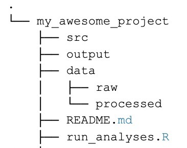

In this structure, we see this reflected by having a data/ folder (a source), a folder for the code that performs the operations (src/) and a place to put the results (output/). The root analysis file (the sole R file on the top level) is responsible for launching and orchestrating the functions defined in the src/ folder’s contents.

## The data folder

The data folder is, unsurprisingly, where your data goes. When it comes to data, it is crucial to make a distinction between source data and generated data. Rich Fitzjohn puts it best when he says to treat source data as read-only, and generated data as disposable. The preferred implementation I have adopted is to have a data/raw/ folder, which is usually is symlinked to a folder that is write-only to clients but read-only to the R user, a data/temp/ folder, which contains temp data, and a data/output/ folder, if warranted.

## The src folder

There are two systems of nomenclature that have worked really well for me and people I work with:

The library model: in this case, the root folder of src/ holds individual .R scripts that when executed will carry out an analysis. There may be one or more such scripts, e.g. for different analyses or different depths of insight. Subfolders of src/ are named after the kind of scripts they contain, e.g. ETL, transformation, plotting. The risk with this structure is that sometimes it’s tricky to remember what’s where, so descriptive file names are particularly important. The pipeline model: in this case, there is a main runner script or potentially a small number. These go through scripts in a sequence. It is a sensible idea in such a case to establish sequential subfolders or sequentially numbered scripts that are executed in sequence. Typically, this model performs better if there are at most a handful distinct pipelines. Whichever approach you adopt, a crucial point is to keep function definition and application separate. This means that only the pipeline or the runner scripts are allowed to execute (apply) functions, and other files are merely supposed to define them. Typically, folder level segregation works best for this:

keep all function definitions in subfolders of src/, e.g. src/data_engineering, and have the directly-executable scripts directly under src/ (this works better for larger projects), or keep function definitions in src/, and keep the directly executable scripts in the root folder (this is more convenient for smaller projects, where perhaps the entire data engineering part is not much more than a single script).

# Prime Hints For Running A Data Project In R

This section is entirely based on the website: https://kkulma.github.io/2018-03-18-Prime-Hints-for-Running-a-data-project-in-R/ Posted on March 18, 2018

===========================================

I’ve been asked more and more for hints and best practices when working with R. It can be a daunting task, depending on how deep or specialised you want to be. So I tried to keep it as balanced as I could and mentioned point that definitely helped me in the last couple of years. Finally, there’s lots (and I mean, LOTS) of good advice out there that you should definitely check out - see some examples in the Quick Reference section below.

### **1. Use R projects. Always.**

Human Civilization was built on conventions. R scripts have them, too. For example > Any resident R script is written assuming that it will be run from a fresh R process with working directory set to the project directory. It creates everything it needs, in its own workspace or folder, and it touches nothing it did not create.

You want your project to work. Not only now, but also in 5 years, even if folder and file paths have changed. Also, you want it to work when your collaborator runs it from their computer. Projects create convention that make it possible.

Basically, they create the environment where

1. all code and outputs are stored in one set location (no more `setwd()`!)
2. relative file paths are created - this guarantees better reproducibility
3. clean R environment is created every time you open it (no more `rm(list = ls())`!)

If you’re not convinced, read [a more thorough explanation given by Jenny Bryan](https://www.tidyverse.org/articles/2017/12/workflow-vs-script/).

So, go on and start a New Project today! Otherwise, your computer may be at risk of being set on fire…

### **2. Describe the purpose of your code / project.**

Before you even load the packages or import the data, state the purpose and content of your script in hashed code.

```
### Data import and cleaning from sources A, B and C.
### This script is part of Segmentation project.
```

Naturally, you can update it along the way, but having such description in place from day one will guarantee that whoever has access to your script will instantly know what he/she is looking at. Also, if you leave it for later, the chances are that you’ll forget to do it altogether and believe me, in X months time when you go back to your code it won’t be that clear what were you trying to do here.

### **3. Load all necessary packages in the beginning of your script & consider calling functions in a package via `::`.**

Ok, I know how it is: you load some basic packages to start with, but then the analysis takes to wondrous and wonderful places that require more specialized libraries. So you install and load them along the way… WRONG! Whenever you have to load a new package, go back to the beginning of your script and load them there. This way whenever you (or someone else) have to run the script again, they will have ALL necessary libraries to run it and won’t get stuck somewhere in the middle of the execution because the function they called is not recognized. It’s coding. Small things matter.

Also, if you don’t want to load the whole package just for the sake of using a single function, consider specifying package directly via `::`. Use this text cleaning exercise as an example:

```
library(readr)
library(dplyr)

tweets <- read_csv("tweets.csv")

all_tweets <- tweets %>%
  rename(author = handle) %>%
  select(author, text) %>%
  mutate(text = qdapRegex::rm_url(text)) %>% #removes URLs from text
  na.omit()
```

Here, I’m expecting to use `readr` and `dplyr` packages regularly and I’m using `qdapRegex` library only once - to remove URL’s from my tweet data. In this case I call `rm_url()` once and I specify the package that it comes from. More about in [here](https://stackoverflow.com/a/23232888). Easy peasy.

#### **!!! UPDATE !!!**

As [Brent Auble](https://twitter.com/brentauble/status/975667201595277313) correctly pointed out, if you decide to use `::` way of calling the package, make sure to put the comment clarifying that you’re going to use this package - preferrably in the load section of the script - so that the user installs the package before running the script.

Also, [Maëlle Salmon](https://twitter.com/ma_salmon) made me realise that there’s already an excellent package packup that organises your code so that any mentioned libraries anywhere in the script automatically end up in the beginning of your code. Genius!

### **4. Name your code sections and use them for quick navigation.**

Your code will grow. Sometimes it will turn into an R script equivalent of the Bible, at least in terms of volume. To keep it organized, keep your code nice and tidy by assigning relevant code chunks to different sections that can be later folded/unfolded; you can also easily navigate yourself through chunks by using ‘drop-up’ menu at the bottom of the script screen.

You create a new code section by writing `####` or `----` at the end of any comment that is to become a new code section.

See the image below for a simplified example:

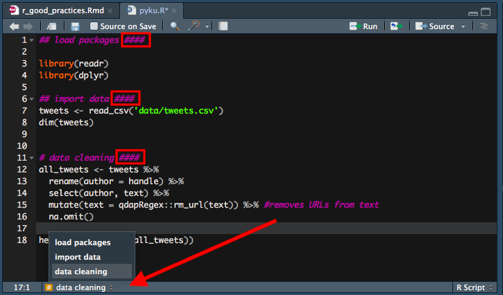

#### **!!! UPDATE !!!**

There’s even a [keyboard shortcut](https://support.rstudio.com/hc/en-us/articles/200711853-Keyboard-Shortcuts) in RStudio for inserting code sections: `Ctrl+Shift+R` for Windows users and `Command+Shift+R` for Mac users. Even [Hadley Wickham can tell you that!](https://twitter.com/hadleywickham/status/975711350130327552)

### **5. Make your life easier and mark your code when you need to.**

Did you know that if you click anywhere left from line numbers in RStudio, it will create a red mark?

[figure not shown]

If you leave it in the script while running the code, it will start a debugging process and therefore stop executing your code. Therefore **always remember to remove the red dot when you run/source your code!!**. Still, I find it pretty useful for temporary marking purposes ;)

### **6. Write your code as if someone was going to use it without communicating with you. From. Day. One.**

I know, I know. We all mean to do it, but we rarely do. I always promise myself that I’ll be thoroughly commenting my code from the very beginning of the project but even these days I find it difficult to do it consistently. Why? Because:

- analysis itself is more important (I’m telling myself).
- I know what I’m doing.
- I (usually) have no direct collaborators that are using the code.

But how short-sighted those arguments are! The reality is that

- even most precious and relevant piece of analysis is useless if you or others don’t understand it (more about it below)
- you know what you’re doing at the moment, but it won’t feel the same way in a month or two when you have moved on to another project but someone asked you an innocent question about how you defined that key variable… Our memory is fallible. Make sure you don’t have to rely on it with every single piece of code you produce
- even you don’t have active collaborators at the time of doing analysis, someone will have to use your code sooner or later. You’re not going to be in the same position for the rest of your life. You’re creating legacy that ONE DAY someone will use, no matter how far away it seems right now.

What makes good, reproducible code?

- generous and clear comments
- logical and efficient code
- code that is ideally timed and tested

#### **!!! UPDATE !!!**

I had discussions online and offline whether your code alone can be used as sufficient documentation. The argument is that clean and clear code should stand for itself, no comments are necessary. There was a time when I thought that, too, but as [Mark Sellors](https://twitter.com/sellorm/status/975845659420119041) pointed out: any code will explain what you did, but it will rarely say WHY you did it. So comment your code generously, please!

### **7. Name your files like a Pro.**

Jenny Bryan is probably the first very high profile R-user I know who’s been actively highlighting the importance of things that not many people talk about: file naming is one of them. I’m not going to reinvent the excellent wheel that she has already invented, so I’m only going to summarize her advice here. But for more detail, please, please, have a look at [Jenny’s slides](https://t.co/99waX8liuQ).

So, what do all good file names have in common? They are:

#### **MACHINE READABLE **

This means that file names are

- regular expression and globbing friendly. Meaning? You can search them using key words (with `regex` and/or `stringr` package). In order to make that easier/possible, remember to avoid spaces, punctuation, accented characters, case sensitivity.

This way it will be easy to search for files later and/or narrow file lists based on names.

Jenny’s example:

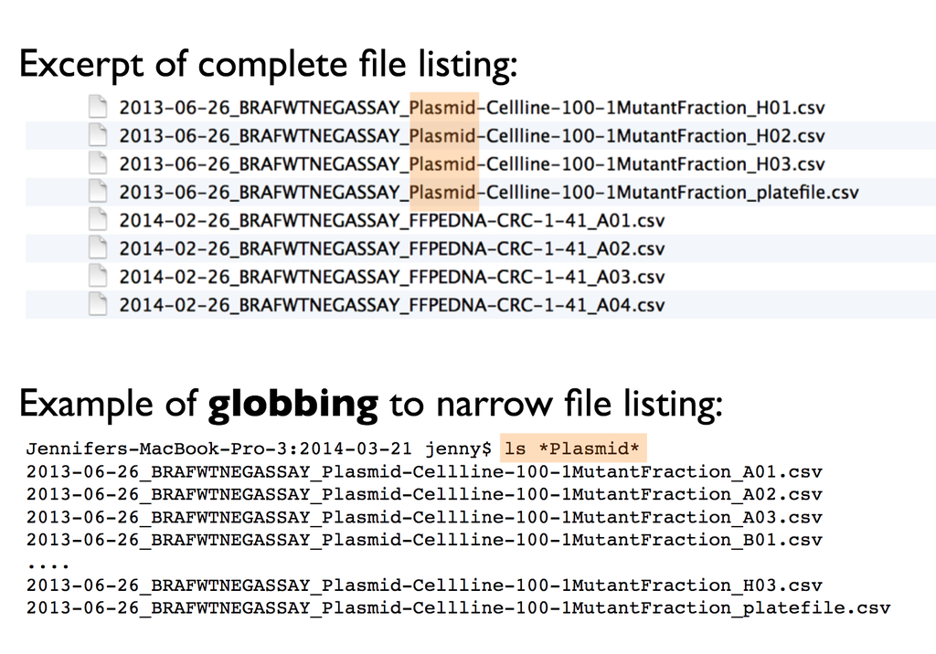

- easy to compute on using delimiters: this means that the file names should have a consistent name structure, where each section of the name has its role and is separated from other name sections with delimiters. This way it will be easy to extract information from file names, e.g. by splitting.

#### **HUMAN READABLE**

Human readable means exactly what is says on the tin:

> Easy to figure out what the heck something is, based on its name, as simple as that :)

I should add, it’s easy to figure it out also for someone who doesn’t know your work very well (this is a clear reminder of the previous point). I love the example below:

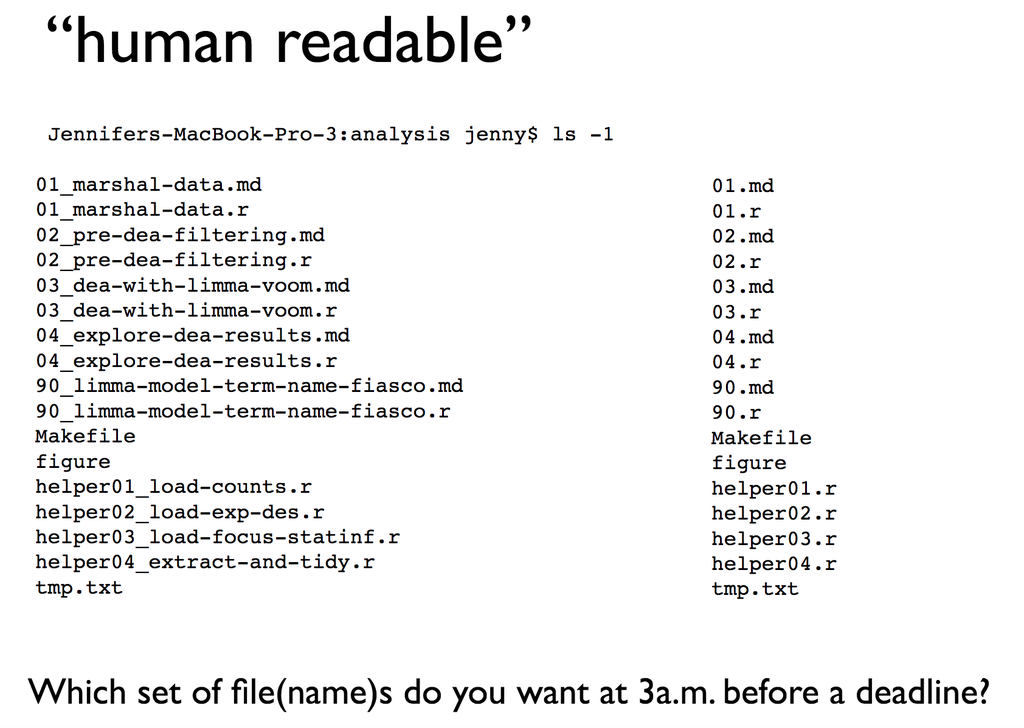

#### **THEY PLAY WELL WITH DEFAULT ORDERING**

The reality is that your computer will sort your files for you, no matter whether you like/need it or not. Therefore:

- put something numeric in your file name first - if the order of sourcing files doesn’t matter, stating when the file was created is always useful. Otherwise, you can indicate the logical order of the files (I’ll come back to that in point 9).
- use the `YYYY-MM-DD` format for dates (it’s ISO 8601 standard!) EVEN when you’re American :)
- left pad other numbers with zeroes - otherwise you’ll end up with `10` before `1` and so on.

Again, one of Jenny’s examples:

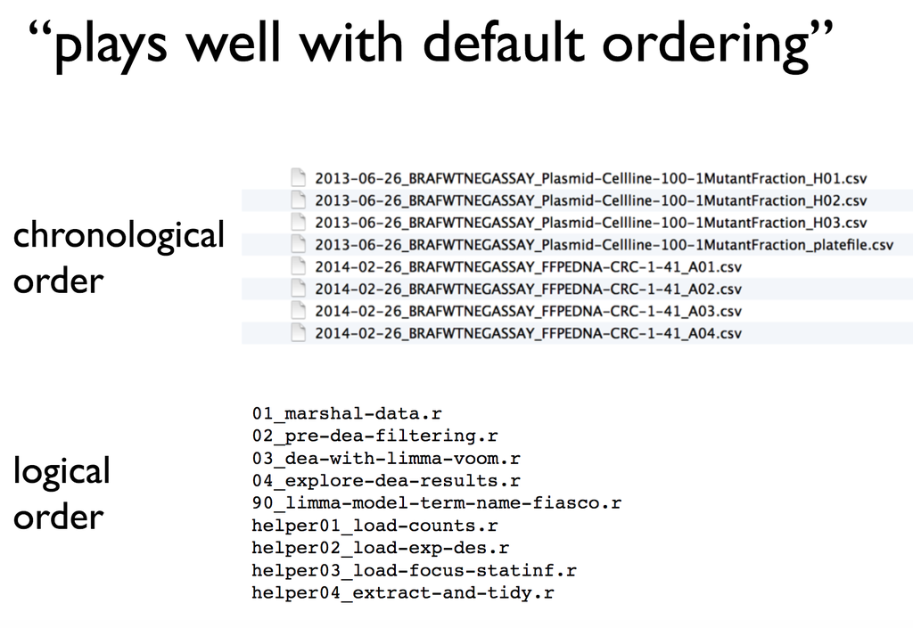

I couldn’t believe how much these little hacks improved the flow of my work. Paying attention to file names was also appreciated by my coworkers, I’m sure.

### **08. If you have to copy/paste excerpt of code 3 or more times, write a function for it.**

.. as Hadley Wickham said many many times in his and Charlotte’s [course on DataCamp](https://www.datacamp.com/courses/writing-functions-in-r/). It doesn’t only teach you to write more elegant and efficient code, but also it makes it more readable for yourself and others.

To learn how to write good functions, you can have a sneak peak into the first chapter of the DataCamp course for free (the rest is available under paid subscription) or read this [DataCamp tutorial](https://www.datacamp.com/community/tutorials/functions-in-r-a-tutorial).

### **09. With big, complex data projects use project pipeline.**

I’m not sure if `project pipeline` is an official name for what I want to talk about, but for a sake of the argument, let’s call it a `project pipeline` ;) Namely, sometimes running a full project from one script - with even clearest and informatively named code sections - is simply difficult, if not unfeasible. Particularly when big(ish) data is involved: imagine trying to run a hefty model on data that requires importing and cleaning, where import into R alone takes about an hour (real life scenario!). You wouldn’t possibly want to do it every time you open the project, right?

So what you do instead is write one script for data import and save the data.frame with useful data as an .RData file (using, e.g. `save(data1, file = "data.RData")`. Then start a new script for, let’s say, data cleaning where you load previously imported data.frame from the .RData file (using `load("data.RData")`). Then you clean the data and save it as yet another .RData file. Then you write the third script where you load the clean data.frame from the second .RData file and you use it to run your model. Jenny Bryan’s advice on file naming comes in handy here, as you want to name and order your scripts or their outputs logically to avoid surprises in the future.

This way you create a clear structure of building blocks, as well inputs and outputs. Additionally, once the data has been imported and cleaned, you can jump straight away into next steps of analysis/modelling without wasting any time on the first two steps.

I started using this approach in big and complex projects after reading [this SO answer](https://stackoverflow.com/a/1434424) and I never looked back.

#### **!!! UPDATE !!!**

Lots of comments regarding this one.

First, I didn’t mention it explicitly, but it mentioned in the Stack Overflow reply I refer to: if you define a number of functions, it’s a good practice to define them in a separate script that you can later source. [Blazko](http://disq.us/p/1r2d3ga) is clearly a fan of this solution :)

Secondly, saving your data objects as `.rds` file is probably a better solution than using `.RData`, as you can directly assing it to another object in a new session (right, [Kees Mulder](https://twitter.com/keestimmulder/status/975854141401595904) ?) or assign a bunch of similar object into a list (wink wink, [Martin Johnsson](https://twitter.com/mrtnj/status/975856756927750145) ). It’s also an official recommendation of [Jenny Bryan](https://twitter.com/JennyBryan/status/975856014019903489).

Finally, if you need a reproducible way of running a number of connected script and/or visualising how they are connected, search no more: [drake package](https://github.com/ropensci/drake) is here to help! Really impressive tool, had no idea it existed at the time of writing this post, so thanks [Peter Higgins](https://twitter.com/ibddoctor/status/975731013266673665) for telling me about it.

### **10. Never save your workspace.**

Again, there were others that already said it before me and said it much better than I would have. So there you go:

> Loading a saved workspace turns your R script from a program, where everything happens logically according to the plan that is the code, to something akin to a cardboard box taken down from the attic, full of assorted pages and notebooks that may or may not be what they seem to be. You end up having to put an inordinate trust in your old self. I don’t know about your old selves, dear reader, but if they are anything like mine, don’t save your workspace.

For details, see [Martin Johnsson](https://twitter.com/mrtnj)’s excellent [blog post](https://martinsbioblogg.wordpress.com/2017/04/02/using-r-dont-save-your-workspace/) that I quoted above.

### **11. Before publishing/sharing your code, run it in the fresh workspace.**

This almost goes without saying, but if I got a £ for every time I forgot to do it… Basically, stuff happens when you write your code: you work with multiple files, maybe you loaded a package in one of them but forgot to do it in the rest of them? If that’s the case, you’ll be able to run all scripts in this particular session but if you send someone the code without the imported function… they will fail to run it. The same will happen if you try to run the script on its own, on your own machine.

Anyway, this doesn’t need much explaining. Simply make sure that you re-run your code in a fresh session before you take it further. Amen.

### **That’s it for now.**

So.. these are my ‘prime hints’ - if someone had told me about them 2 years ago, my `#rstats` life would have been much much easier. By no means is this list complete or exhaustive, but my intention was to highlight the points that I personally found most useful in my daily fun with R. Hope it will help someone!

#### **General good practice**

1. [Five Tips to Improve Your R Code (DataCamp)](https://www.datacamp.com/community/tutorials/five-tips-r-code-improve)
2. [Workflow for statistical analysis and report writing (SO)](https://stackoverflow.com/questions/1429907/workflow-for-statistical-analysis-and-report-writing/1434424#1434424)
3. [R Best Practices: R you writing the R way! (By Milind Paradkar)](https://www.quantinsti.com/blog/r-best-practices-r-you-writing-the-r-way/)
4. [Good practices in R programming (Indiana University)](https://kb.iu.edu/d/aaxp)

.

# Assignment 3.

Write an R-function that gives you the predicted change in precipitation and temperature for a region, but the future rainfall should represent the mean of different models. the function should be able to accept an argument for with specific model should be used. The possible CMIP6 models are One of > `"ACCESS-CM2", "ACCESS-ESM1-5", "AWI-CM-1-1-MR", "BCC-CSM2-MR", "CanESM5", "CanESM5-CanOE", "CMCC-ESM2", "CNRM-CM6-1", "CNRM-CM6-1-HR", "CNRM-ESM2-1", "EC-Earth3-Veg", "EC-Earth3-Veg-LR", "FIO-ESM-2-0", "GFDL-ESM4", "GISS-E2-1-G", "GISS-E2-1-H", "HadGEM3-GC31-LL", "INM-CM4-8", "INM-CM5-0", "IPSL-CM6A-LR", "MIROC-ES2L", "MIROC6", "MPI-ESM1-2-HR", "MPI-ESM1-2-LR", "MRI-ESM2-0", "UKESM1-0-LL"`.

You can create this function by combining the functions described above. Also create a clear graphical representation of your workflow, similar to the example given above. The following examples can help you:

Define a variable with specific `models` `models <- c("ACCESS-CM2", "ACCESS-ESM1-5")` Loop over these models to download the precipitation predictions You can add layers to a SpatRaster object using the function `add()` from the terra package. Make use of pipes `%>%` where you can. Make sure you adhere to the best coding practices and create a clear project structure (see above section on basic project structure). Have fun!